# IODS course project

## Bonus: Some more clustering

The data was clustered into 5.

```r
# k-means clustering
km <-kmeans(dist_eu, centers = 5)

# plot the Boston dataset with clusters
pdf(file = "plots/Boston_cluster_pairplot_K5.pdf")
pairs(Boston, col = km$cluster, lower.panel = NULL, gap=0.5, pch = 16, cex =0.1)
dev.off()
```

```r
# change the object to data frame
boston_scaled <- as.data.frame(boston_scaled)

# linear discriminant analysis
lda.fit.clusters <- lda(km$cluster ~ . , data = boston_scaled)

# the function for lda biplot arrows
lda.arrows <- function(x, myscale = 1, arrow_heads = 0.1, color = "red", tex = 0.75, choices = c(1,2)){
  heads <- coef(x)
  arrows(x0 = 0, y0 = 0,
         x1 = myscale * heads[,choices[1]],
         y1 = myscale * heads[,choices[2]], col=color, length = arrow_heads)
  text(myscale * heads[,choices], labels = row.names(heads),
       cex = tex, col=color, pos=3)
}

# target classes as numeric
classes <- as.numeric(km$cluster)

# plot the lda results
pdf(file = "plots/Boston_cluster_LDA.pdf")
plot(lda.fit.clusters, dimen = 2, col = classes, pch = classes)
lda.arrows(lda.fit.clusters, myscale = 3)
dev.off()
```

## Super-Bonus

The following plot is a projection of the model predictors for crime rate. The colour denotes the crime categories.

```r
model_predictors <- dplyr::select(train, -crime)

# check the dimensions
dim(model_predictors)
```

```
## [1] 404  13
```

```r
dim(lda.fit$scaling)
```

```
## [1] 13  3
```

```r
# matrix multiplication
matrix_product <- as.matrix(model_predictors) %*% lda.fit$scaling
matrix_product <- as.data.frame(matrix_product)


library(plotly)
plot_ly(x = matrix_product$LD1, y = matrix_product$LD2, z = matrix_product$LD3, type= 'scatter3d', mode='markers', color = train$crime)
```

[interactive chart not shown]

In the following plot, the colour denotes 4 clusters produced by k-means analysis.

```r
# k-means clustering
dist_eu <- dist(train)
```

```r
km <-kmeans(dist_eu, centers = 4)

library(plotly)
plot_ly(x = matrix_product$LD1, y = matrix_product$LD2, z = matrix_product$LD3, type= 'scatter3d', mode='markers', color = km$cluster)
```

[interactive chart not shown]

The crime categories are quite nicely separated in the projection of model predictors. Observations with high crime rates are separated from the other observations. The 4 clusters from the k-means clustering do not completely overlap with crime categories. Cluster 3 has greates overlap with the high crime rate category. However, the clustering depends on the training set which is different every time I knit the file.

# 5. Dimensionality reduction techniques

## 1. The human dataset

```r
# load the data
human <- read.csv("data/human.csv")

# add countries as rownames
rownames(human) <- human$X

# explore the dataset
str(human)
```

```
## 'data.frame':    155 obs. of  9 variables:
##  $ X                 : Factor w/ 155 levels "Afghanistan",..: 105 6 134 41 101 54 67 149 28 102 ...
##  $ edu2_ratio        : num  1.007 0.997 0.983 0.989 0.969 ...
##  $ labour_ratio      : num  0.891 0.819 0.825 0.884 0.829 ...
##  $ life_exp          : num  81.6 82.4 83 80.2 81.6 80.9 80.9 79.1 82 81.8 ...
##  $ edu_exp           : num  17.5 20.2 15.8 18.7 17.9 16.5 18.6 16.5 15.9 19.2 ...
##  $ GNI               : int  64992 42261 56431 44025 45435 43919 39568 52947 42155 32689 ...
##  $ maternal_mortality: int  4 6 6 5 6 7 9 28 11 8 ...
##  $ adolescent_birth  : num  7.8 12.1 1.9 5.1 6.2 3.8 8.2 31 14.5 25.3 ...
##  $ parliament_repr   : num  39.6 30.5 28.5 38 36.9 36.9 19.9 19.4 28.2 31.4 ...
```

```r
dim(human)
```

```
## [1] 155   9
```

The human dataset includes data from 155 countries on human development and gender inequality from the human development reports from the United Nations. Variables describing human development are life expectancy at birth (life_exp), expected years of schooling (edu_exp) and gross national income per capita (GNI). Gender inequality is described by the ratio between women and men with at least secondary education (edu2_ratio), the ratio between female and male particiation rates in the labour force (labour_ratio), the maternal mortality ratio (maternal_mortality), the birth rate among adolescents (adolescent_birth) and percentage of female representation in parliament (parliament_repr).

## 2. Exploring the human data set

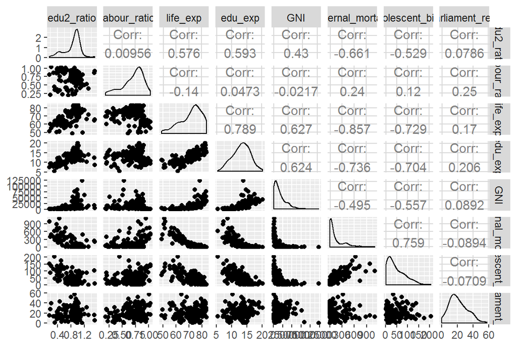

```r
library(GGally)
library(dplyr)


human_ <- select(human, -X)

# visualize the variables
ggpairs(human_)
```

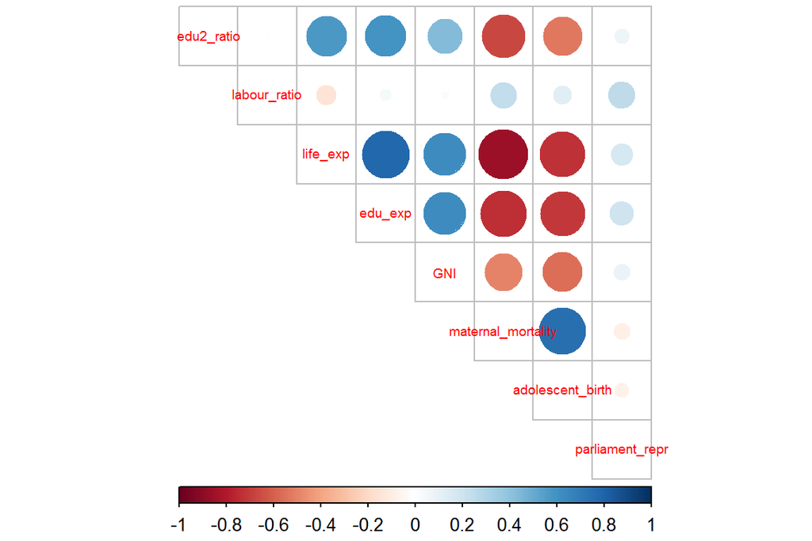

```r
library(corrplot)

cor_matrix<-cor(human_)
corrplot(cor_matrix, method="circle", type = "upper", cl.pos = "b", tl.pos = "d", tl.cex = 0.6)
```

```r
summary(human_)
```

```
##    edu2_ratio      labour_ratio       life_exp        edu_exp
##  Min.   :0.1717   Min.   :0.1857   Min.   :49.00   Min.   : 5.40
##  1st Qu.:0.7264   1st Qu.:0.5984   1st Qu.:66.30   1st Qu.:11.25
##  Median :0.9375   Median :0.7535   Median :74.20   Median :13.50
##  Mean   :0.8529   Mean   :0.7074   Mean   :71.65   Mean   :13.18
##  3rd Qu.:0.9968   3rd Qu.:0.8535   3rd Qu.:77.25   3rd Qu.:15.20
##  Max.   :1.4967   Max.   :1.0380   Max.   :83.50   Max.   :20.20
##       GNI         maternal_mortality adolescent_birth parliament_repr
##  Min.   :   581   Min.   :   1.0     Min.   :  0.60   Min.   : 0.00
##  1st Qu.:  4198   1st Qu.:  11.5     1st Qu.: 12.65   1st Qu.:12.40
##  Median : 12040   Median :  49.0     Median : 33.60   Median :19.30
##  Mean   : 17628   Mean   : 149.1     Mean   : 47.16   Mean   :20.91
##  3rd Qu.: 24512   3rd Qu.: 190.0     3rd Qu.: 71.95   3rd Qu.:27.95
##  Max.   :123124   Max.   :1100.0     Max.   :204.80   Max.   :57.50
```

For the ratio between women and men with at least secondary education (edu2_ratio), half of the countries have ratios between 0.73 and 1, very few countries have more women than men with at least secondary education.

The ratio between female and male particiation rates in the labour force (labour_ratio) is between 0.60 and 0.85 in 50% of the countries. There are only four countries where more women than men are participating in the labour force.

The life expectancy at birth (life_exp) varies a lot between countries, from a minimal of 49 to a maximum of 83.5. In 50% of countries, life expentancy is between 66 and 77.

The expected years of schooling (edu_exp) is normally distributed. There is huge variation between countries, varying between a minimal of 5 to a maximum of 20 years of education.

Maternal mortality ratio is below 200 for most countries, but there are a few countries for which the maternal mortality ratio is fairly high.

Most countrie shave adolescent birth rate below 50

The representation of women in parliament is only 20% in most countries. Only 2 countries have representation of higher than 50%.

There are strong positive correlations between life expectancy and expected years of schooling. As life is longer, people spend more time at school. The maternal mortality rate and adolescent birth rate have strong positive correlation. There is a strong negative correlation between life expectany and maternal mortality rate. Both variables describe the quality of health care in a country. Consequently, life expectancy and expected years of schooling both have strong negative correlation with maternal mortality rate and adolescent birth rate.

## 3. Principal component analysis (PCA)

A principal component analysis (PCA) was performed on the data.

```r
# perform principal component analysis (with the SVD method)
pca_human <- prcomp(human_)

summary(pca_human)
```

```
## Importance of components:
##                              PC1      PC2   PC3   PC4   PC5   PC6    PC7
## Standard deviation     1.854e+04 185.5219 25.19 11.45 3.766 1.566 0.1912
## Proportion of Variance 9.999e-01   0.0001  0.00  0.00 0.000 0.000 0.0000
## Cumulative Proportion  9.999e-01   1.0000  1.00  1.00 1.000 1.000 1.0000
##                           PC8
## Standard deviation     0.1591
## Proportion of Variance 0.0000
## Cumulative Proportion  1.0000
```

```r
# draw a biplot of the principal component representation and the original variables
pdf(file = "plots/human_pca.pdf")
biplot(pca_human, choices = 1:2, cex = c(0.5, 1), col = c("grey40", "red"))
dev.off()
```

## 4. Principal component analysis (PCA) after standardizing

```r
# standardize the variables
human_std <- scale(human_)

# perform principal component analysis (with the SVD method)
pca_human_std <- prcomp(human_std)

summary(pca_human)
```

```
## Importance of components:
##                              PC1      PC2   PC3   PC4   PC5   PC6    PC7
## Standard deviation     1.854e+04 185.5219 25.19 11.45 3.766 1.566 0.1912
## Proportion of Variance 9.999e-01   0.0001  0.00  0.00 0.000 0.000 0.0000
## Cumulative Proportion  9.999e-01   1.0000  1.00  1.00 1.000 1.000 1.0000
##                           PC8
## Standard deviation     0.1591
## Proportion of Variance 0.0000
## Cumulative Proportion  1.0000
```

```r
# Change the labels of the arrows
rownames(pca_human_std$rotation) <- c("gender equality in education","gender equality in the work","life expectancy","duration of schooling","income","maternal mortality rate","adolescent birth rate","representation of women in politics")

# draw a biplot of the principal component representation and the original variables
pdf(file = "plots/human_std_pca.pdf")
biplot(pca_human_std, choices = 1:2, cex = c(0.5, 0.3), col = c("grey40", "red"))
dev.off()
```

## 6. The tea dataset

The data used here concern a questionnaire on tea. 300 individuals were asked how they drink tea (18 questions), what their product’s perception is (12 questions) and some personal details (4 questions) (from: https://artax.karlin.mff.cuni.cz/r-help/library/FactoMineR/html/tea.html).

```r
library(FactoMineR)

data("tea")

#Exploring the tea data
summary(tea)
```

```
##          breakfast           tea.time          evening          lunch
##  breakfast    :144   Not.tea time:131   evening    :103   lunch    : 44
##  Not.breakfast:156   tea time    :169   Not.evening:197   Not.lunch:256
##
##
##
##
##
##         dinner           always          home           work
##  dinner    : 21   always    :103   home    :291   Not.work:213
##  Not.dinner:279   Not.always:197   Not.home:  9   work    : 87
##
##
##
##
##
##         tearoom           friends          resto          pub
##  Not.tearoom:242   friends    :196   Not.resto:221   Not.pub:237
##  tearoom    : 58   Not.friends:104   resto    : 79   pub    : 63
##
##
##
##
##
##         Tea         How           sugar                     how
##  black    : 74   alone:195   No.sugar:155   tea bag           :170
##  Earl Grey:193   lemon: 33   sugar   :145   tea bag+unpackaged: 94
##  green    : 33   milk : 63                  unpackaged        : 36
##                  other:  9
##
##
##
##                   where                 price          age        sex
##  chain store         :192   p_branded      : 95   Min.   :15.00   F:178
##  chain store+tea shop: 78   p_cheap        :  7   1st Qu.:23.00   M:122
##  tea shop            : 30   p_private label: 21   Median :32.00
##                             p_unknown      : 12   Mean   :37.05
##                             p_upscale      : 53   3rd Qu.:48.00
##                             p_variable     :112   Max.   :90.00
##
```

[output cut: 25 more lines]

```
##  feminine    :129   Not.sophisticated: 85   No.slimming:255
##  Not.feminine:171   sophisticated    :215   slimming   : 45
##
##
##
##
##
##         exciting          relaxing              effect.on.health
##  exciting   :116   No.relaxing:113   effect on health   : 66
##  No.exciting:184   relaxing   :187   No.effect on health:234
##
##
##
##
##
```

```r
str(tea)
```

```
## 'data.frame':    300 obs. of  36 variables:
##  $ breakfast       : Factor w/ 2 levels "breakfast","Not.breakfast": 1 1 2 2 1 2 1 2 1 1 ...
##  $ tea.time        : Factor w/ 2 levels "Not.tea time",..: 1 1 2 1 1 1 2 2 2 1 ...
##  $ evening         : Factor w/ 2 levels "evening","Not.evening": 2 2 1 2 1 2 2 1 2 1 ...
##  $ lunch           : Factor w/ 2 levels "lunch","Not.lunch": 2 2 2 2 2 2 2 2 2 2 ...
##  $ dinner          : Factor w/ 2 levels "dinner","Not.dinner": 2 2 1 1 2 1 2 2 2 2 ...
##  $ always          : Factor w/ 2 levels "always","Not.always": 2 2 2 2 1 2 2 2 2 2 ...
##  $ home            : Factor w/ 2 levels "home","Not.home": 1 1 1 1 1 1 1 1 1 1 ...
##  $ work            : Factor w/ 2 levels "Not.work","work": 1 1 2 1 1 1 1 1 1 1 ...
##  $ tearoom         : Factor w/ 2 levels "Not.tearoom",..: 1 1 1 1 1 1 1 1 1 2 ...
##  $ friends         : Factor w/ 2 levels "friends","Not.friends": 2 2 1 2 2 2 1 2 2 2 ...
##  $ resto           : Factor w/ 2 levels "Not.resto","resto": 1 1 2 1 1 1 1 1 1 1 ...
##  $ pub             : Factor w/ 2 levels "Not.pub","pub": 1 1 1 1 1 1 1 1 1 1 ...
##  $ Tea             : Factor w/ 3 levels "black","Earl Grey",..: 1 1 2 2 2 2 2 1 2 1 ...
##  $ How             : Factor w/ 4 levels "alone","lemon",..: 1 3 1 1 1 1 1 3 3 1 ...
```

[output cut: 22 more lines]

```r
dim(tea)
```

```
## [1] 300  36
```

```r
#drop the age (factorized in age_Q)
tea <- select(tea, -age)

library(ggplot2)
library(tidyr)

# visualize the dataset
dev.new(width=5, height=50)
pdf(file = "plots/tea_ggplot.pdf")
gather(tea) %>% ggplot(aes(value)) + facet_wrap("key", scales = "free") + geom_bar() + theme(axis.text.x = element_text(angle = 30, hjust = 1, size =4 ))
dev.off()
```

```r
# column names to keep in the dataset
keep_columns <- c("age_Q", "price", "SPC", "tearoom", "where")

# select the 'keep_columns' to create a new dataset
my_tea <- select(tea, one_of(keep_columns))

# multiple correspondence analysis
mca <- MCA(my_tea, method = "indicator", graph = FALSE)

# summary of the model
summary(mca)
```

```
##
## Call:
## MCA(X = my_tea, graph = FALSE, method = "indicator")
##
##
## Eigenvalues
##                        Dim.1   Dim.2   Dim.3   Dim.4   Dim.5   Dim.6
## Variance               0.431   0.342   0.292   0.265   0.238   0.232
## % of var.             11.969   9.498   8.120   7.356   6.625   6.431
## Cumulative % of var.  11.969  21.467  29.587  36.943  43.568  49.999
##                        Dim.7   Dim.8   Dim.9  Dim.10  Dim.11  Dim.12
## Variance               0.211   0.209   0.203   0.192   0.184   0.174
## % of var.              5.865   5.810   5.626   5.331   5.120   4.839
## Cumulative % of var.  55.863  61.673  67.299  72.630  77.750  82.588
##                       Dim.13  Dim.14  Dim.15  Dim.16  Dim.17  Dim.18
## Variance               0.162   0.134   0.126   0.081   0.067   0.057
## % of var.              4.503   3.724   3.510   2.242   1.862   1.571
## Cumulative % of var.  87.091  90.816  94.325  96.568  98.429 100.000
##
## Individuals (the 10 first)
##                    Dim.1    ctr   cos2    Dim.2    ctr   cos2    Dim.3
## 1               | -0.019  0.000  0.000 |  1.025  1.024  0.139 |  0.201
## 2               |  0.071  0.004  0.002 |  0.507  0.251  0.100 |  0.155
## 3               |  0.018  0.000  0.000 |  0.542  0.286  0.072 |  0.005
## 4               | -0.789  0.482  0.388 | -0.275  0.074  0.047 | -0.598
## 5               | -0.223  0.038  0.024 |  0.323  0.102  0.050 |  0.246
## 6               | -1.092  0.923  0.304 | -0.288  0.081  0.021 | -0.472
## 7               |  0.238  0.044  0.017 |  0.594  0.344  0.107 | -0.404
## 8               |  0.164  0.021  0.009 |  0.603  0.355  0.118 | -0.116
## 9               |  0.948  0.696  0.206 |  0.550  0.295  0.069 | -0.476
## 10              |  1.270  1.248  0.313 |  0.537  0.281  0.056 | -0.956
##                    ctr   cos2
## 1                0.046  0.005 |
## 2                0.027  0.009 |
## 3                0.000  0.000 |
## 4                0.408  0.223 |
## 5                0.069  0.029 |
## 6                0.254  0.057 |
## 7                0.186  0.049 |
## 8                0.015  0.004 |
```

[output cut: 19 more lines]

```
## 45-59             0.084   4.999 |   0.381   2.024   0.037   3.332 |
## +60               0.543 -12.738 |   0.581   2.929   0.049   3.828 |
## p_branded         0.009  -1.666 |   0.652   9.223   0.197   7.680 |
## p_cheap           0.019  -2.398 |   1.136   2.061   0.031   3.037 |
## p_private label   0.000  -0.189 |  -0.344   0.568   0.009  -1.634 |
## p_unknown         0.063   4.341 |   0.171   0.080   0.001   0.603 |
## p_upscale         0.003   0.932 |   0.226   0.619   0.011   1.813 |
##
## Categorical variables (eta2)
##                   Dim.1 Dim.2 Dim.3
## age_Q           | 0.539 0.783 0.235 |
## price           | 0.416 0.088 0.359 |
## SPC             | 0.523 0.777 0.308 |
## tearoom         | 0.174 0.000 0.262 |
## where           | 0.502 0.061 0.298 |
```

```r
# visualize MCA
pdf(file = "plots/tea_mca.pdf")
plot(mca, invisible=c("ind"), habillage = "quali")
dev.off()
```